# PEC 3

Dic 14, 2020

El objetivo de la PEC es elaborar un análisis estadístico en R de un caso práctico con datos de obtención propia (pertenecientes a un determinado ámbito), lo más ajustado a la realidad. A continuación, podéis encontrar una serie de pautas para su realización:

# Ejercicio 1 (1 punto)

**Buscar un conjunto de datos relacionados con la Bioestadística o la Bioinformática. Posibles recursos bibliográficos son aquellos presentados en la PEC1, por ejemplo: http://www.bioinformatics.org/sms2/index.html; o bien http://biostat.mc.vanderbilt.edu/wiki/Main/DataSets. También es posible utilizar fuentes propias o de interés, siempre teniendo en cuenta que sean datos públicos para los usuarios. Será necesario especificar la procedencia y la justificación de la elección de los datos.**

Este conjunto de datos puede ser útil para estudiar que variables influyen en la aparición de esta enfermedad, el CHD.

Tomar como base para explicar los datos esto:

he WCGS began in 1960 with 3,524 male volunteers who were employed by 11 California companies. Subjects were 39 to 59 years old and free of heart disease as determined by electrocardiogram. After the initial screening, the study population dropped to 3,154 and the number of companies to 10 because of various exclusions. The cohort comprised both blue- and white-collar employees. At baseline the following information was collected: socio-demographic including age, education, marital status, income, occupation; physical and physiological including height, weight, blood pressure, electrocardiogram, and corneal arcus; biochemical including cholesterol and lipoprotein fractions; medical and family history and use of medications; behavioral data including Type A interview, smoking, exercise, and alcohol use. Later surveys added data on anthropometry, triglycerides, Jenkins Activity Survey, and caffeine use. Average follow-up continued for 8.5 years with repeat examinations

# Ejercicio 2 (1 punto)

**Utilizando R, mostrar y explicar qué tipo de ficheros se han importado, las variables de estudio (tipo, clasificación, …), así como todo aquello relevante para el estudio. Incluir capturas de pantalla y las instrucciones en R utilizadas para importar y mostrar los datos.**

Este estudio consta de 13 variables. Estas son algunas medidas físicas y clínicas de un conjunto de 3154 hombres. Una descripción más detallada de estas es:

- age: edad en años
- height: altura en pulgadas
- weight: peso en libras
- sdp: presión sistólica en mm Hg
- dbp: presión diastólica en mm Hg
- chol: nivel de colesterol sérico en ayunas
- behave: tipo de comportamiento (niveles ‘A1’, ‘A2’, ‘A3’, ‘A4’)?
- cigs: número diario de cigarrillos fumados
- dibep: tipo de comportamiento con niveles ‘A’ (Agresivo) y ‘B’ (pasivo)
- chd: si ha desarrollado CHD(coronary heart disease), tiene niveles ‘no’ y ‘yes’
- typechd: tipo de CHD desarrollado, tiene niveles ‘angina’, ‘infdeath’, ‘none’, ‘silent’
- timechd: tiempo hasta que se ha desarrollado el CHD (cuanto se detectó) o finalización del seguimiento
- arcus: arco senil (mancha en la pupila), tiene niveles ‘absent’ ‘present’.

Los primeros registros del dataset se muestran a continuación:

```r
head(data)
```

|  | age | height | weight | sdp | dbp | chol | behave | cigs | dibep | chd | typechd | timechd | arcus |
| --- | --- | --- | --- | --- | --- | --- | --- | --- | --- | --- | --- | --- | --- |
| 1 | 49 | 73 | 150 | 110 | 76 | 225 | A2 | 25 | B | no | none | 1664 | absent |
| 2 | 42 | 70 | 160 | 154 | 84 | 177 | A2 | 20 | B | no | none | 3071 | present |
| 3 | 42 | 69 | 160 | 110 | 78 | 181 | B3 | 0 | A | no | none | 3071 | absent |
| 4 | 41 | 68 | 152 | 124 | 78 | 132 | B4 | 20 | A | no | none | 3064 | absent |
| 5 | 59 | 70 | 150 | 144 | 86 | 255 | B3 | 20 | A | yes | infdeath | 1885 | present |
| 6 | 44 | 72 | 204 | 150 | 90 | 182 | B4 | 0 | A | no | none | 3102 | absent |

Algunas características del dataset y sus variables son:

```r
dim(data) # número de filas y columnas
```

```
## [1] 3154   13
```

```r
str(data) # estructura de las variables
```

```
## 'data.frame':    3154 obs. of  13 variables:
##  $ age    : int  49 42 42 41 59 44 44 40 43 42 ...
##  $ height : int  73 70 69 68 70 72 72 71 72 70 ...
##  $ weight : int  150 160 160 152 150 204 164 150 190 175 ...
##  $ sdp    : int  110 154 110 124 144 150 130 138 146 132 ...
##  $ dbp    : int  76 84 78 78 86 90 84 60 76 90 ...
##  $ chol   : int  225 177 181 132 255 182 155 140 149 325 ...
##  $ behave : Factor w/ 4 levels "A1","A2","B3",..: 2 2 3 4 3 4 4 2 3 2 ...
##  $ cigs   : int  25 20 0 20 20 0 0 0 25 0 ...
##  $ dibep  : Factor w/ 2 levels "A","B": 2 2 1 1 1 1 1 2 1 2 ...
##  $ chd    : Factor w/ 2 levels "no","yes": 1 1 1 1 2 1 1 1 1 1 ...
##  $ typechd: Factor w/ 4 levels "angina","infdeath",..: 3 3 3 3 2 3 3 3 3 3 ...
##  $ timechd: int  1664 3071 3071 3064 1885 3102 3074 3071 3064 1032 ...
##  $ arcus  : Factor w/ 2 levels "absent","present": 1 2 1 1 2 1 1 1 1 2 ...
```

Podemos comprobar si existen valores faltantes y/o nulos en el conjunto de datos:

```r
sum(is.na(data))    # comprobar datos missing
```

```
## [1] 14
```

```r
sum(is.null(data))  # comprobar datos null
```

```
## [1] 0
```

Vemos que hay 14 datos faltantes. Podemos eliminar las filas que los contengan y seguir con ese nuevo conjunto de datos para el estudio. Las nuevas dimensiones del dataset son:

```r
data <- na.omit(data) # filtro dataset sin NA
dim(data)
```

```
## [1] 3140   13
```

Además, podemos crear una nueva variable `fumador`, que será un factor que toma valores ‘si’ y ‘no’, a partir de la información de la variable `cigs`:

```r
data$fumador <- ifelse(data$cigs>0, "si", "no") # creación variable fumador
table(data$fumador)
```

```
##
##   no   si
## 1646 1494
```

Vemos que el 47.6% de los hombres del estudio son fumadores.

Por otro lado, podemos transformar a otras unidades (m y kg) las variables `height` y `weight` con las siguientes funciones y crear la variable `IMC`, a partir de la fórmula $IMC=\frac{kg}{m^2}$:

```r
# Funciones cambio de unidades:

to_m <- function(variable){
  new_units <- variable / 39.370
  return(new_units)
}

to_kg <- function(variable){
  new_units <- variable / 2.2046
  return(new_units)
}
```

```r
# Transformación unidades
data$height <- to_m(data$height)
data$weight <- to_kg(data$weight)

# Nueva variable IMC
data$IMC <- data$weight/data$height^2
```

En este caso no ha sido necesario importar ningún fichero de datos porque este dataset ya viene incorporado en R. Por este motivo vamos a mostrar como exportaríamos los datos a ficheros .csv y .txt. Los exportamos sin indicar directorio así que se guardaran en la carpeta de trabajo que tengamos configurada al ejecutar este script.

- .csv

```r
write.csv(data, file = "datos_wcgs.csv")  # exportar a .csv
tail(read.csv("datos_wcgs.csv"))          # importar y ver últimos registros
```

|  | X | age | height | weight | sdp | dbp | chol | behave | cigs | dibep | chd | typechd | timechd | arcus | fumador | IMC |
| --- | --- | --- | --- | --- | --- | --- | --- | --- | --- | --- | --- | --- | --- | --- | --- | --- |
| 3135 | 3149 | 46 | 1.752604 | 58.06042 | 126 | 74 | 268 | A2 | 40 | B | no | none | 3119 | present | si | 18.90222 |
| 3136 | 3150 | 41 | 1.778004 | 78.47229 | 124 | 78 | 215 | A2 | 0 | B | no | none | 3056 | absent | no | 24.82282 |
| 3137 | 3151 | 45 | 1.752604 | 90.71940 | 144 | 82 | 261 | B3 | 0 | A | no | none | 3056 | absent | no | 29.53472 |
| 3138 | 3152 | 50 | 1.778004 | 74.84351 | 122 | 82 | 242 | A2 | 50 | B | no | none | 2383 | present | si | 23.67494 |
| 3139 | 3153 | 39 | 1.727203 | 76.20430 | 126 | 76 | 213 | B3 | 0 | A | no | none | 3053 | absent | no | 25.54421 |
| 3140 | 3154 | 39 | 1.701803 | 70.30754 | 150 | 88 | 264 | A1 | 40 | B | no | none | 3055 | absent | si | 24.27633 |

- .txt

```r
write.table(data, file = "datos_wcgs.txt")  # exportar a .txt
tail(read.table("datos_wcgs.txt"))          # importamos y ver últimos registros
```

|  | age | height | weight | sdp | dbp | chol | behave | cigs | dibep | chd | typechd | timechd | arcus | fumador | IMC |
| --- | --- | --- | --- | --- | --- | --- | --- | --- | --- | --- | --- | --- | --- | --- | --- |
| 3149 | 46 | 1.752604 | 58.06042 | 126 | 74 | 268 | A2 | 40 | B | no | none | 3119 | present | si | 18.90222 |
| 3150 | 41 | 1.778004 | 78.47229 | 124 | 78 | 215 | A2 | 0 | B | no | none | 3056 | absent | no | 24.82282 |
| 3151 | 45 | 1.752604 | 90.71940 | 144 | 82 | 261 | B3 | 0 | A | no | none | 3056 | absent | no | 29.53472 |
| 3152 | 50 | 1.778004 | 74.84351 | 122 | 82 | 242 | A2 | 50 | B | no | none | 2383 | present | si | 23.67494 |
| 3153 | 39 | 1.727203 | 76.20430 | 126 | 76 | 213 | B3 | 0 | A | no | none | 3053 | absent | no | 25.54421 |
| 3154 | 39 | 1.701803 | 70.30754 | 150 | 88 | 264 | A1 | 40 | B | no | none | 3055 | absent | si | 24.27633 |

# Ejercicio 3 (2 puntos)

**Con la Sección 2 de la PEC1 como base, elaborar y analizar una serie de cuestiones, que ayuden a explorar y a familiarizarse mejor con los datos de estudio. Además, en algunos casos, puede utilizarse la definición de funciones y el lenguaje SQL estudiado en el LAB3.**

A continuación analizaremos los datos para poder vislumbrar el valor que pueden aportar las variables. Para ello, presentaremos una serie de observaciones y cuestiones sobre los mismos.

Como se ha explicado anteriormente, el grupo de estudio correponde a un grupo de hombres. Vamos a hacernos una idea del grupo de estudio.

Los datos estadisticos de todas las columnas

|  | age | height | weight | sdp | dbp |
| --- | --- | --- | --- | --- | --- |
|  | Min. :39.00 | Min. :1.524 | Min. : 35.38 | Min. : 98.0 | Min. : 58.00 |
|  | 1st Qu.:42.00 | 1st Qu.:1.727 | 1st Qu.: 70.31 | 1st Qu.:120.0 | 1st Qu.: 76.00 |
|  | Median :45.00 | Median :1.778 | Median : 77.11 | Median :126.0 | Median : 80.00 |
|  | Mean :46.27 | Mean :1.772 | Mean : 77.09 | Mean :128.6 | Mean : 81.97 |
|  | 3rd Qu.:50.00 | 3rd Qu.:1.829 | 3rd Qu.: 82.55 | 3rd Qu.:136.0 | 3rd Qu.: 86.00 |
|  | Max. :59.00 | Max. :1.981 | Max. :145.15 | Max. :230.0 | Max. :136.00 |

|  | chol | behave | cigs | dibep | chd |
| --- | --- | --- | --- | --- | --- |
|  | Min. :103.0 | A1: 263 | Min. : 0.00 | A:1557 | no :2885 |
|  | 1st Qu.:197.0 | A2:1320 | 1st Qu.: 0.00 | B:1583 | yes: 255 |
|  | Median :223.0 | B3:1209 | Median : 0.00 |  |  |
|  | Mean :226.3 | B4: 348 | Mean :11.58 |  |  |
|  | 3rd Qu.:253.0 |  | 3rd Qu.:20.00 |  |  |
|  | Max. :645.0 |  | Max. :99.00 |  |  |

|  | typechd | timechd | arcus | fumador | IMC |
| --- | --- | --- | --- | --- | --- |
|  | angina : 51 | Min. : 18 | absent :2202 | no:1646 | Min. :11.19 |
|  | infdeath: 134 | 1st Qu.:2843 | present: 938 | si:1494 | 1st Qu.:22.96 |
|  | none :2885 | Median :2942 |  |  | Median :24.39 |
|  | silent : 70 | Mean :2684 |  |  | Mean :24.52 |
|  |  | 3rd Qu.:3036 |  |  | 3rd Qu.:25.84 |
|  |  | Max. :3430 |  |  | Max. :38.95 |

La edad, estatura y peso medios son 46.27 años, 1.77 m y 77.09 kg. Como datos a tener en cuenta podemos ver que el nivel de colesterol serico en ayunas tiene un rango muy amplio, con un min de 103 y un max de 645. Este dato podemos contrastarlo mediante el calculo de la desviación estandar.

```r
colesterol_sd <- sd(data$chol)
colesterol_sd
```

```
## [1] 43.42108
```

En el siguiente paso, vamos a comprobar la dependencia que tienen las variables entre si. Sabemos que todas las variables no son cuantitativas, por lo tanto, vamos a aislarlas en un vector y a continuación ver que correlación hay entre ellas.

```r
data_cuantitativa <- data[, c(1,2,3,4,5,6,8,12,15)] #Aislar los datos
#A continuación, nombramos las columnas
colnames(data_cuantitativa) <- c('Edad', 'Altura', 'Peso', 'P.sis', 'P.diast',
                                 'Colesterol', 'N/d cigarrillos', 'Tipo CHD', 'IMC')

#Redondeamos el resultado
correlación <- round(cor(data_cuantitativa), digits = 2)
kable(correlación)
```

|  | Edad | Altura | Peso | P.sis | P.diast | Colesterol | N/d cigarrillos | Tipo CHD | IMC |
| --- | --- | --- | --- | --- | --- | --- | --- | --- | --- |
| Edad | 1.00 | -0.09 | -0.03 | 0.17 | 0.14 | 0.09 | -0.01 | -0.07 | 0.03 |
| Altura | -0.09 | 1.00 | 0.53 | 0.02 | 0.01 | -0.09 | 0.02 | -0.01 | -0.06 |
| Peso | -0.03 | 0.53 | 1.00 | 0.25 | 0.29 | 0.01 | -0.08 | -0.07 | 0.81 |
| P.sis | 0.17 | 0.02 | 0.25 | 1.00 | 0.77 | 0.12 | 0.03 | -0.11 | 0.29 |
| P.diast | 0.14 | 0.01 | 0.29 | 0.77 | 1.00 | 0.13 | -0.06 | -0.11 | 0.34 |
| Colesterol | 0.09 | -0.09 | 0.01 | 0.12 | 0.13 | 1.00 | 0.10 | -0.09 | 0.07 |
| N/d cigarrillos | -0.01 | 0.02 | -0.08 | 0.03 | -0.06 | 0.10 | 1.00 | -0.10 | -0.11 |
| Tipo CHD | -0.07 | -0.01 | -0.07 | -0.11 | -0.11 | -0.09 | -0.10 | 1.00 | -0.07 |
| IMC | 0.03 | -0.06 | 0.81 | 0.29 | 0.34 | 0.07 | -0.11 | -0.07 | 1.00 |

Obtenemos una representación grafica de la correlación para un análisis mas visual de la misma. Este tema se tratará más en profundidad en el siguiente ejercicio de la PEC.

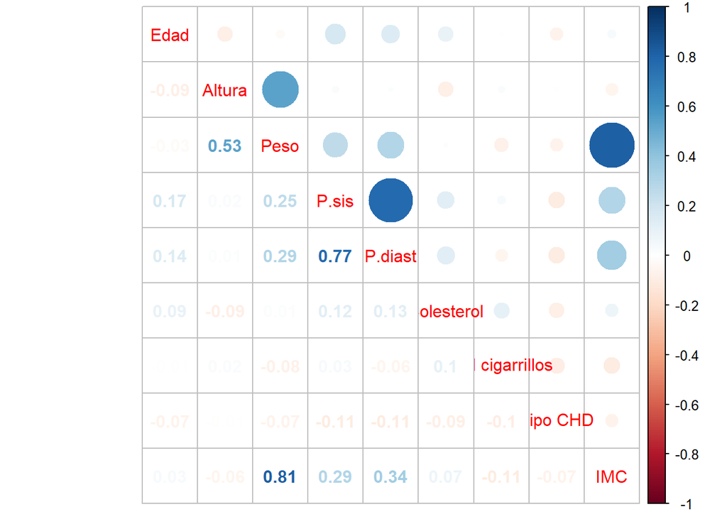

```r
corrplot.mixed(correlación)
```

```r
chol_no_fumador <- 0
chol_si_fumador <- 0

for(i in 1:length(data$chol))
  if (data$fumador[i]=="si") {
    chol_si_fumador <- chol_si_fumador + 1
  } else{
    chol_no_fumador <- chol_no_fumador + 1
  }

porcentaje_chol_nofumador <- (chol_no_fumador/length(data$chol))*100
porcentaje_chol_sifumador <- (chol_si_fumador/length(data$chol))*100
porcentaje_chol_nofumador
```

```
## [1] 52.42038
```

```r
porcentaje_chol_sifumador
```

```
## [1] 47.57962
```

```r
chol_no_fumador_edad <- 0
chol_si_fumador_edad <-0

for(i in 1:length(data$chol))
  if (data$fumador[i]=="si"| data$age[i] > mean(data$age)) {
    chol_si_fumador_edad <- chol_si_fumador_edad + 1
  } else if (data$fumador[i]=="no" | data$age[i] > mean(data$age)) {
    chol_no_fumador_edad <- chol_no_fumador_edad + 1
  }

porcentaje_chol_nofumador2 <- (chol_no_fumador_edad/length(data$chol))*100
porcentaje_chol_sifumador2 <- (chol_si_fumador_edad/length(data$chol))*100
porcentaje_chol_nofumador2
```

```
## [1] 30.31847
```

```r
porcentaje_chol_sifumador2
```

```
## [1] 69.68153
```

Vamos a usar SQL para realizar algún análisis a los datos.En este caso, vamos a estudiar los datos de colesterol de los pacientes que presentan una mancha en la pupila de forma descendente, solo los 6 primeros casos

```r
sqldf("SELECT chol
      FROM data
      WHERE arcus = 'present'
      ORDER BY chol DESC
      LIMIT 6")
```

| chol |
| --- |
| 400 |
| 390 |
| 386 |
| 385 |
| 383 |
| 376 |

Se observa que los hombres con mancha en la pupila presentan niveles de colesterol altos, teniendo en cuenta que la media es de 226.35, es una observación a tener en cuenta en la evaluación visual del paciente.

Ahora, veremos los los niveles de presion en pacientes que fuman una cantidad superior a 50 cigarros al dia y IMC superior a 24

```r
sqldf("SELECT sdp, dbp FROM data where cigs > 50 AND IMC > 24 ")
```

| sdp | dbp |
| --- | --- |
| 134 | 80 |
| 126 | 76 |
| 130 | 80 |
| 146 | 86 |
| 118 | 80 |
| 140 | 86 |
| 142 | 94 |
| 108 | 62 |
| 146 | 88 |
| 116 | 76 |

[output cut: 1 more lines]

En esta sección hemos visualizado la correlación de las variables y mediante algun loop y SQL hemos verificado la misma.

# Ejercicio 4 (1 punto)

Realizar un análisis descriptivo de los datos. El análisis debe incluir (tal y como aparece en la Sección 3 de la PEC1) un resumen paramétrico de los datos y su representación gráfica, que mejor defina y complemente cada una de dichas variables.

En el apartado anterior hemos presentado un resumen estadístico descriptivo de los principales parámetros de estos datos. En este ejercicio vamos a profundizar más en el dataset, incluyendo algunos gráficos interesantes para estudiar el comportamiento de las variables y poder extraer información útil.

Empezamos haciendo un gráfico de dispersión entre las variables cuantitativas del dataset 2 a 2:

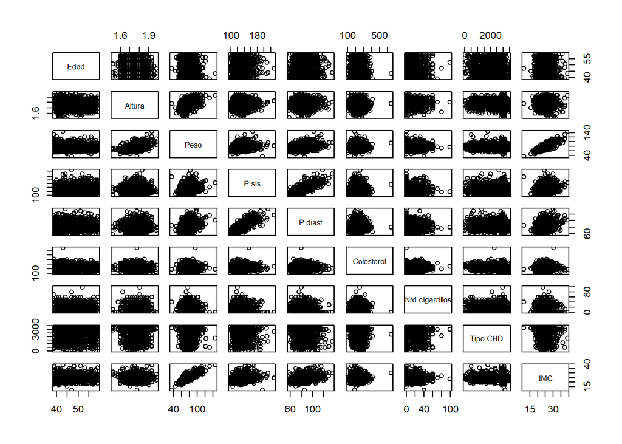

```r
pairs(data_cuantitativa)
```

Se observan las correlaciones entre algunas variables comentadas en el apartado anterior, como entre las variables que miden la presión por ejemplo. En este gráfico podemos deducir a primera vista que entre las variables `IMC` y la presión diastólica existe cierta relación, así que vamos a explorar de manera gráfica como se relacionan estas variables:

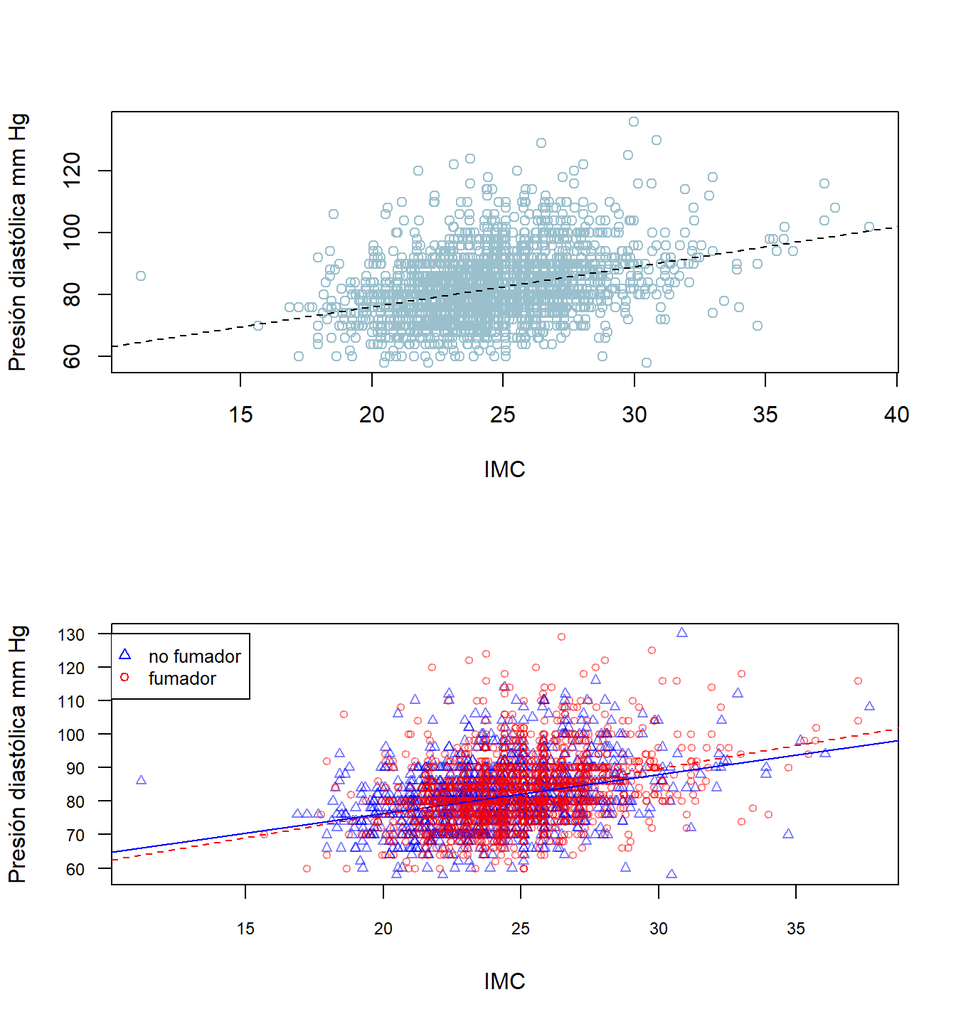

```r
par(mfrow=c(2, 1))
plot(data$dbp ~ data$IMC, xlab = "IMC", ylab = "Presión diastólica mm Hg",
     col = "lightblue3"); abline(lm(data$dbp ~ data$IMC), lty=2)
plot(data$dbp[data$fumador == "si"] ~ data$IMC[data$fumador == "si"],
     xlab = "IMC", ylab = "Presión diastólica mm Hg",
     col = rgb(red = 0, green = 0, blue = 1, alpha = 0.5), pch = 2, cex.axis = 0.75,
     cex = 0.75, las = 1)
points(data$dbp[data$fumador == "no"] ~ data$IMC[data$fumador == "no"],
       col = rgb(red = 1, green = 0, blue = 0, alpha = 0.5), cex = 0.75)
abline(mod_fum, col = "blue"); abline(mod_nofum, col = "red", lty = 2)
legend(10, 130,legend=c("no fumador", "fumador"), col=c("blue", "red"), pch = c(2, 1),
       cex = 0.8)
```

Por otro lado, puede ser interesante estudiar los valores de colesterol según si el hombre es fumador.

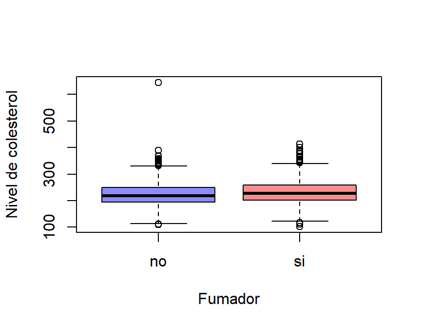

```r
boxplot(data$chol ~ data$fumador, xlab = "Fumador", ylab = "Nivel de colesterol",
        col = c(col = rgb(red = 0, green = 0, blue = 1, alpha = 0.45),
                col = rgb(red = 1, green = 0, blue = 0, alpha = 0.45)))
```

Tanto si el hombre es fumador como si no, la distribución del colesterol presenta algunos outliers. Además, para el grupo de fumadores el nivel de colesterol presenta valores mayores.

En el apartado anterior deducimos que el hecho de tener una mancha en el arco senil (`arcus`) se debía a niveles más altos de colesterol, vamos a graficar también estas dos variables de manera conjunta para profundizar en esta relación. Nos ayudaremos con el paquete ggplot2.

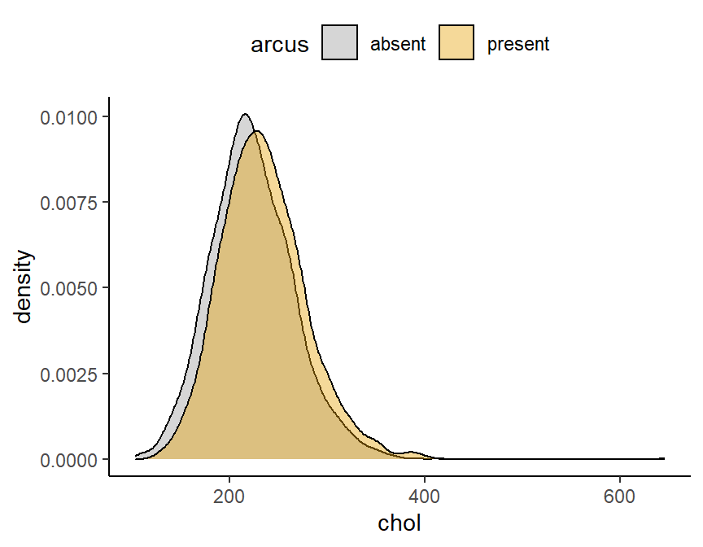

```r
data%>%
ggplot(aes(x = chol, fill = arcus)) + geom_density(alpha=0.4) +
  scale_fill_manual(values=c("#999999", "#E69F00", "#56B4E9")) +
  theme_classic() + theme(legend.position="top")
```

Se observa que la distribución del colesterol tiene forma de Normal para ambos grupos (se podría comprobar con algún test de normalidad) y además para el grupo de hombres que presenta arco seníl es más elevada. Podemos comprobarlo con un t-test.

```r
t.test(data$chol ~ data$arcus)
```

```
##
##  Welch Two Sample t-test
##
## data:  data$chol by data$arcus
## t = -6.871, df = 1780.6, p-value = 8.782e-12
## alternative hypothesis: true difference in means is not equal to 0
## 95 percent confidence interval:
##  -14.800671  -8.227425
## sample estimates:
##  mean in group absent mean in group present
##               222.906               234.420
```

Concluimos que existen diferencias estadísticamente significativas entre las medias de cholesterol de los hombres con arco senil y sin él, siendo mayor el primero.

Ahora vamos a centrarnos más en la variable de interés del estudio, que es el desarrollo de la enfermedad coronaria del corazón. Vamos a estudiar con que posibles variables puede estar relacionada su aparición.

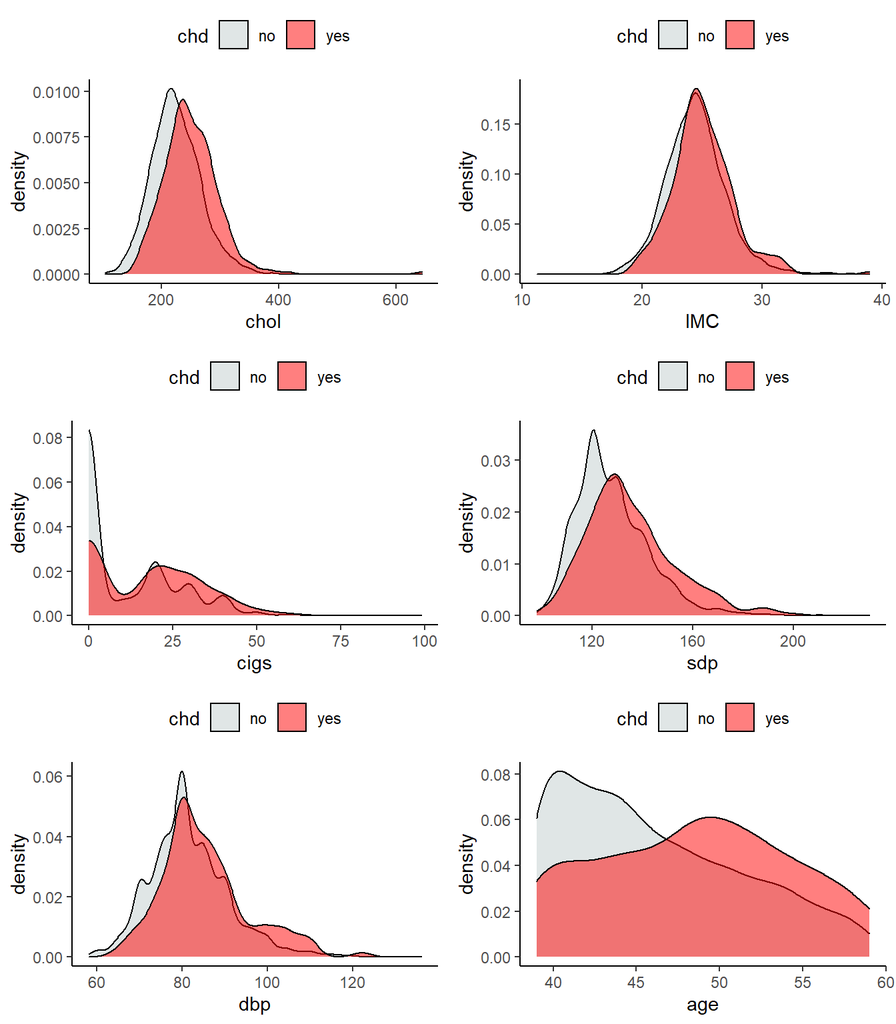

```r
grid.arrange(
data%>%
ggplot(aes(x = chol, fill = chd)) + geom_density(alpha=0.5) +
  scale_fill_manual(values=c("azure3", "red")) +
  theme_classic() + theme(legend.position="top")
,
data%>%
ggplot(aes(x = IMC, fill = chd)) + geom_density(alpha=0.5) +
  scale_fill_manual(values=c("azure3", "red")) +
  theme_classic() + theme(legend.position="top")
,
data%>%
ggplot(aes(x = cigs, fill = chd)) + geom_density(alpha=0.5) +
  scale_fill_manual(values=c("azure3", "red")) +
  theme_classic() + theme(legend.position="top")
,
data%>%
ggplot(aes(x = sdp, fill = chd)) + geom_density(alpha=0.5) +
  scale_fill_manual(values=c("azure3", "red")) +
  theme_classic() + theme(legend.position="top")
,
data%>%
ggplot(aes(x = dbp, fill = chd)) + geom_density(alpha=0.5) +
  scale_fill_manual(values=c("azure3", "red")) +
  theme_classic() + theme(legend.position="top"),

data%>%
ggplot(aes(x = age, fill = chd)) + geom_density(alpha=0.5) +
  scale_fill_manual(values=c("azure3", "red")) +
  theme_classic() + theme(legend.position="top"),
ncol = 2
)
```

Las variables que más se diferencian en la aparición/no aparición de CHD es la edad, las presiones sangíneas y el número de cigarrillos fumados.

Procedemos a analizar que edades tienen los individuos de esta muestra, podemos hacerlo a partir de un diagrama de tallo y hojas. Como tenemos muchos registros, podemos seleccionar una muestra aleatoria de 500 personas para que el diagrama sea visualizable

```r
stem(sample(data$age, 500)) # Diagrama de tallo y hojas de la variable stem
```

```
##
##   The decimal point is at the |
##
##   39 | 000000000000000000000000000000000000000000
##   40 | 000000000000000000000000000000000000000
##   41 | 000000000000000000000000000000
##   42 | 00000000000000000000000000000000000
##   43 | 00000000000000000000000000000000
##   44 | 000000000000000000000000000000000000000
##   45 | 0000000000000000000000000000000000000000000
##   46 | 0000000000000000000000000000000
##   47 | 000000000000000000000000000000
##   48 | 0000000000000000000000000
##   49 | 00000000000000000000
##   50 | 000000000000000000000
##   51 | 0000000000000000000
##   52 | 00000000000000000000
##   53 | 000000000000000
##   54 | 000000000000000000000
##   55 | 0000000000000
##   56 | 0000000
##   57 | 0000
##   58 | 0000
##   59 | 0000000000
```

Notamos que la edad se distribuye de forma decreciente (hay más jovenes que mayores). Seguramente se debe al tipo de trabajo que realizan los hombres de este estudio.

Por otro lado, vamos a analizar los datos de manera más numérica mediante algunas tablas de frecuencias relativas y absolutas. Empezando por la variable `dibep`, tenemos:

```r
round(prop.table(table(data$dibep)), 3) # Frecuencias relativas
```

```
##
##     A     B
## 0.496 0.504
```

El número de hombres con comportamiento agresivo(A) y pasivo (B) es muy similar. Las podemos ver en frecuencias absolutas para ver a que número equivalen estos porcentajes:

```r
table(data$dibep) # Frecuencias absolutas
```

```
##
##    A    B
## 1557 1583
```

Además, podemos observar la tabla de frecuencias cruzadando las variables `fumador` y `diabep`

```r
prop.table(table(data$dibep, data$fumador))*100
```

```
##
##           no       si
##   A 27.51592 22.07006
##   B 24.90446 25.50955
```

Vemos que el grupo caracterizado por tener un comportamiento agresivo (A) tiene más probabilidad de tener individuos no fumadores.

Y cruzando las variables `CHD` y `arcus`:

```r
prop.table(table(data$chd, data$arcus))*100
```

```
##
##          absent   present
##   no  65.254777 26.624204
##   yes  4.872611  3.248408
```

Se observa que en el grupo que tanto si se ha desarrollado el CHD como si no, es más frecuente no encontrar arco seníl, aunque en el grupo que sí tiene CHD la diferencia es menos clara. Es decir, que podríamos relacionar la aparición del arco senil con la enfermedad aunque pueden haber otros efectos confusores como la edad.

En el contexto de este estudio sería interesante estimar un modelo lineal generalizado (logit) con respuesta binaria (0 no CHD, 1 CHD) pero no se ha visto en esta asignatura, así seleccionaremos alguna otra variable del dataset como variable respuesta y veremos con que variable predictora estimaríamos un buen modelo que tenga sentido.

# Ejercicio 5 (1,5 punto)

Complementando el apartado anterior, elaborar un análisis de regresión de dos conjuntos de variables (LAB2 y Ejercicio 6 de la PEC1). La elección de las variables, los resultados, así como su relación deben de estar correctamente justificada.

En este apartado, vamos a realizar una regresión lineal y otra multiple. Para la regresión lineal, hemos elegido las variables de colesterol y edad. Vamos a ver primero la correlación existente entre ambas

```r
cor(data_cuantitativa$Edad, data_cuantitativa$Colesterol)
```

```
## [1] 0.08933263
```

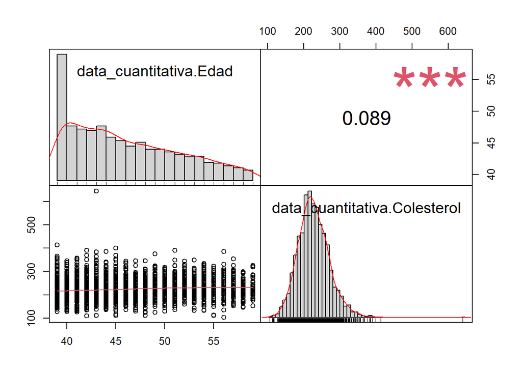

```r
var <- data.frame(data_cuantitativa$Edad, data_cuantitativa$Colesterol)
chart.Correlation(var)
```

Vemos que hay una correlación pobre, tal vez debido a que la mayoria de pacientes del estudio tienen una edad baja. Hemos comprobado las demas variables y tambien tienen una baja correlación. El IMC y el peso tienen una correlación alta, pero porque el IMC se ha calculado a raiz del peso, por lo tanto, elegimos la Edad

Vamos a realizar el modelo

```r
modelo <- lm(formula = data_cuantitativa$Colesterol ~ data_cuantitativa$Edad, data=data_cuantitativa)
summary(modelo)
```

```
##
## Call:
## lm(formula = data_cuantitativa$Colesterol ~ data_cuantitativa$Edad,
##     data = data_cuantitativa)
##
## Residuals:
##     Min      1Q  Median      3Q     Max
## -130.18  -28.86   -2.86   26.07  420.96
##
## Coefficients:
##                        Estimate Std. Error t value Pr(>|t|)
## (Intercept)            193.8104     6.5214  29.719  < 2e-16 ***
## data_cuantitativa$Edad   0.7031     0.1399   5.024 5.34e-07 ***
## ---
## Signif. codes:  0 '***' 0.001 '**' 0.01 '*' 0.05 '.' 0.1 ' ' 1
##
## Residual standard error: 43.25 on 3138 degrees of freedom
## Multiple R-squared:  0.00798,    Adjusted R-squared:  0.007664
## F-statistic: 25.24 on 1 and 3138 DF,  p-value: 5.335e-07
```

Vemos que el p-value esta por debajo de 0.05, podemos decir entonces que hay una asosiación estadistica significatica entre nuestras dos variables. Aun asi, no debemos perder de vista el “Multiple R-squared”. este numero nos indica el pocentaje de variación en el colesterol que puede ser explicado mediante la edad del paciente. Si tenemos un valor alto explicaria mejor la relación entre las variables. En este caso, tenemos un valor muy bajo. Un rango mayor en la Edad de los pacientes nos ayudaria mas a vislumbrar la relación real entre la Edad y el colesterol.

Vamos a ver nuestro modelo en un grafico

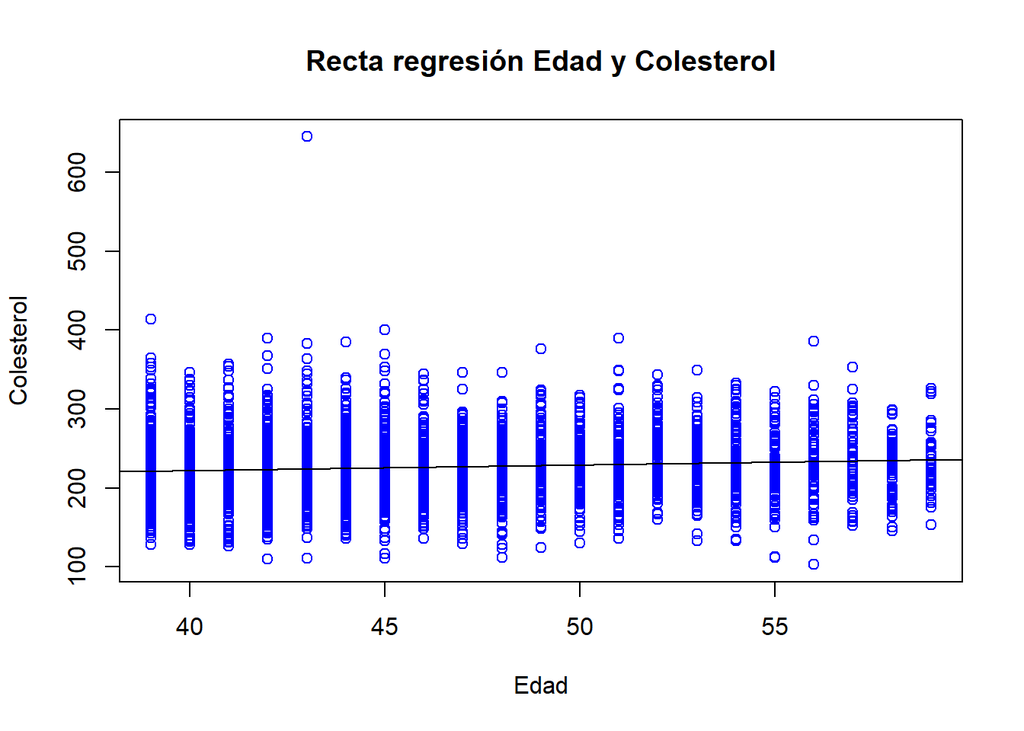

```r
plot(data_cuantitativa$Colesterol ~ data_cuantitativa$Edad, col="blue", xlab= "Edad", ylab="Colesterol", main="Recta regresión Edad y Colesterol")
abline(modelo)
```

Mediante un analisis visual confirmamos la baja correlación entre nuestras variables.

Vamos a calcular los residuos del modelo ajustado anterior y realizaremos un gráfico de normalidad

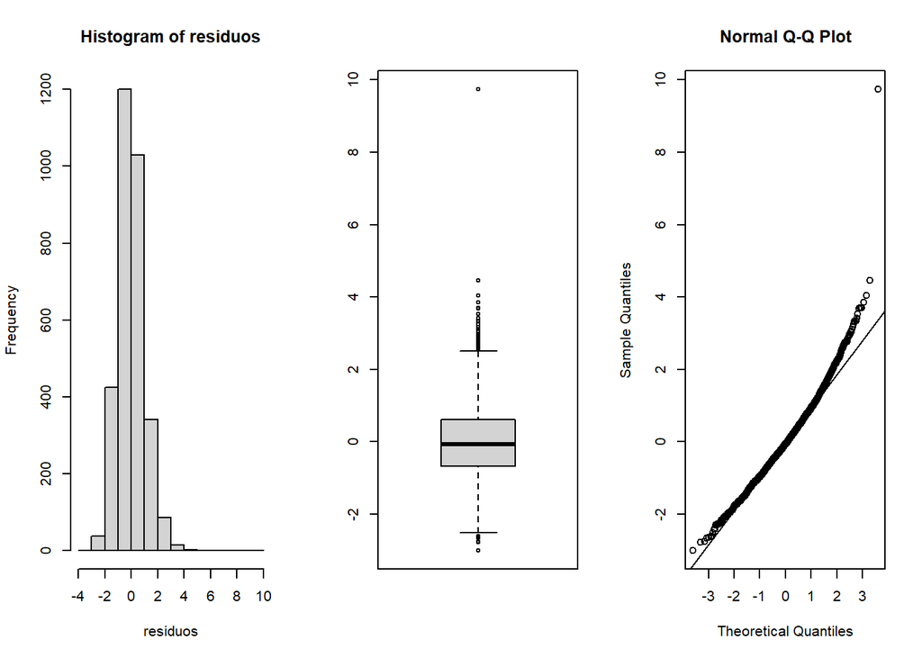

```r
residuos<-rstandard(modelo) # residuos estándares del modelo ajustado
par(mfrow=c(1,3))
hist(residuos) # histograma de los residuos estandarizados
boxplot(residuos) # diagrama de cajas de los residuos estandarizados
qqnorm(residuos) # gráfico de cuantiles de los residuos estandarizados
qqline(residuos) # dibujamos la reta en el gráfico anterior
```

Para ver si podemos resolver parte del problema, realizaremos una regresión multiple.

Como hemos apreciado antes, no hay mucha correlación entre las variables. Vamos a general el modelo de regresión múltiple añadiendo mas variables.

```r
mrm <- lm(data$chol
          ~data$age+data$weight+data$sdp+data$dbp+data$behave+data$cigs+data$dibep+data$chd+data$typechd+data$arcus+data$fumador+data$IMC)
summary(mrm)
```

```
##
## Call:
## lm(formula = data$chol ~ data$age + data$weight + data$sdp +
##     data$dbp + data$behave + data$cigs + data$dibep + data$chd +
##     data$typechd + data$arcus + data$fumador + data$IMC)
##
## Residuals:
##     Min      1Q  Median      3Q     Max
## -122.48  -28.35   -2.10   24.88  393.94
##
## Coefficients: (2 not defined because of singularities)
##                       Estimate Std. Error t value Pr(>|t|)
## (Intercept)          157.16692   10.87090  14.458  < 2e-16 ***
## data$age               0.21534    0.14164   1.520 0.128539
## data$weight           -0.67525    0.13336  -5.063 4.36e-07 ***
## data$sdp               0.02804    0.07905   0.355 0.722788
## data$dbp               0.43867    0.12489   3.512 0.000450 ***
## data$behaveA2         -3.68264    2.83048  -1.301 0.193332
## data$behaveB3         -4.83800    2.86663  -1.688 0.091569 .
## data$behaveB4         -6.07494    3.44180  -1.765 0.077653 .
## data$cigs              0.08488    0.09517   0.892 0.372489
## data$dibepB                 NA         NA      NA       NA
## data$chdyes           22.86386    5.95155   3.842 0.000125 ***
## data$typechdinfdeath   7.36702    6.89313   1.069 0.285266
## data$typechdnone            NA         NA      NA       NA
## data$typechdsilent   -23.25352    7.70136  -3.019 0.002553 **
## data$arcuspresent      9.54959    1.66897   5.722 1.15e-08 ***
## data$fumadorsi         5.80378    2.76007   2.103 0.035566 *
## data$IMC               2.75452    0.50572   5.447 5.53e-08 ***
## ---
## Signif. codes:  0 '***' 0.001 '**' 0.01 '*' 0.05 '.' 0.1 ' ' 1
##
## Residual standard error: 41.78 on 3125 degrees of freedom
## Multiple R-squared:  0.07811,    Adjusted R-squared:  0.07398
## F-statistic: 18.91 on 14 and 3125 DF,  p-value: < 2.2e-16
```

Vemos que la determinación de “Multiple R-squared” es bastante baja como cabria esperar. Vamos a seleccionar los mejores entre todos los predictores

```r
step(object = mrm, direction = "both", trace=1)
```

```
## Start:  AIC=23455.16
## data$chol ~ data$age + data$weight + data$sdp + data$dbp + data$behave +
##     data$cigs + data$dibep + data$chd + data$typechd + data$arcus +
##     data$fumador + data$IMC
##
##
## Step:  AIC=23455.16
## data$chol ~ data$age + data$weight + data$sdp + data$dbp + data$behave +
##     data$cigs + data$dibep + data$typechd + data$arcus + data$fumador +
##     data$IMC
##
##
## Step:  AIC=23455.16
## data$chol ~ data$age + data$weight + data$sdp + data$dbp + data$behave +
##     data$cigs + data$typechd + data$arcus + data$fumador + data$IMC
##
##                Df Sum of Sq     RSS   AIC
## - data$behave   3      6502 5462474 23453
## - data$sdp      1       220 5456192 23453
## - data$cigs     1      1389 5457361 23454
## <none>                      5455972 23455
## - data$age      1      4035 5460008 23456
## - data$fumador  1      7720 5463692 23458
## - data$dbp      1     21539 5477512 23466
## - data$weight   1     44759 5500731 23479
## - data$IMC      1     51796 5507769 23483
## - data$arcus    1     57160 5513133 23486
## - data$typechd  3    135477 5591449 23526
##
## Step:  AIC=23452.9
## data$chol ~ data$age + data$weight + data$sdp + data$dbp + data$cigs +
##     data$typechd + data$arcus + data$fumador + data$IMC
##
##                Df Sum of Sq     RSS   AIC
## - data$sdp      1       176 5462650 23451
## - data$cigs     1      1829 5464303 23452
## <none>                      5462474 23453
## + data$dibep    1      3138 5459336 23453
## - data$age      1      4921 5467395 23454
## - data$fumador  1      7361 5469836 23455
```

[output cut: 45 more lines]

```
##     data$arcus + data$fumador + data$IMC + data$dibep
##
##                Df Sum of Sq     RSS   AIC
## <none>                      5461041 23450
## - data$dibep    1      3510 5464551 23450
## - data$age      1      4392 5465433 23451
## + data$cigs     1      1562 5459479 23451
## + data$sdp      1       199 5460842 23452
## + data$behave   2      3392 5457649 23452
## - data$weight   1     44333 5505374 23474
## - data$fumador  1     47529 5508570 23475
## - data$IMC      1     51992 5513033 23478
## - data$dbp      1     55833 5516874 23480
## - data$arcus    1     57721 5518762 23481
## - data$typechd  3    137601 5598642 23522
```

```
##
## Call:
## lm(formula = data$chol ~ data$age + data$weight + data$dbp +
##     data$typechd + data$arcus + data$fumador + data$IMC + data$dibep)
##
## Coefficients:
##          (Intercept)              data$age           data$weight
##             174.9764                0.2236               -0.6716
##             data$dbp  data$typechdinfdeath      data$typechdnone
##               0.4734                7.3064              -23.0494
##   data$typechdsilent     data$arcuspresent        data$fumadorsi
##             -23.1793                9.5906                7.9472
##             data$IMC           data$dibepB
##               2.7589                2.1422
```

Las variables que mejores resultados nos pueden dar como predictores son las que vemos en “Call”. Realizamos el modelo de regresión multiple con los predictores seleccionados

```r
mrm_predictores <- (lm(formula = data$chol ~ data$age + data$weight + data$dbp +
    data$typechd + data$arcus + data$fumador + data$IMC + data$dibep))
summary(mrm_predictores)
```

```
##
## Call:
## lm(formula = data$chol ~ data$age + data$weight + data$dbp +
##     data$typechd + data$arcus + data$fumador + data$IMC + data$dibep)
##
## Residuals:
##     Min      1Q  Median      3Q     Max
## -122.82  -27.96   -1.98   24.92  393.93
##
## Coefficients:
##                       Estimate Std. Error t value Pr(>|t|)
## (Intercept)          174.97643   12.32734  14.194  < 2e-16 ***
## data$age               0.22361    0.14096   1.586 0.112766
## data$weight           -0.67158    0.13325  -5.040 4.92e-07 ***
## data$dbp               0.47337    0.08369   5.656 1.69e-08 ***
## data$typechdinfdeath   7.30638    6.88462   1.061 0.288653
## data$typechdnone     -23.04943    5.94152  -3.879 0.000107 ***
## data$typechdsilent   -23.17934    7.69607  -3.012 0.002617 **
## data$arcuspresent      9.59058    1.66768   5.751 9.74e-09 ***
## data$fumadorsi         7.94715    1.52288   5.218 1.92e-07 ***
## data$IMC               2.75894    0.50548   5.458 5.19e-08 ***
## data$dibepB            2.14216    1.51061   1.418 0.156268
## ---
## Signif. codes:  0 '***' 0.001 '**' 0.01 '*' 0.05 '.' 0.1 ' ' 1
##
## Residual standard error: 41.78 on 3129 degrees of freedom
## Multiple R-squared:  0.07725,    Adjusted R-squared:  0.0743
## F-statistic:  26.2 on 10 and 3129 DF,  p-value: < 2.2e-16
```

En este caso, hemos reducido el numero de predictores. Aun asi, los datos obtenidos en la regresión multiple no han mejorado.

Aunque hayamos seleccionado variables que es sabido que aumentan las probabilidades de sufrir problemas de corazon y aumento de colesterol, no hemos podido verificarlo con los datos del estudio. Aun asi, esto nos puede servir para dar información sobre un mejor diseño de los pacientes del estudio. Variar la población en el rango de edad, hacer un estudio analogo con mujeres…

# Ejercicio 6 (1 punto)

Realizar, a partir de los conceptos trabajados en el LAB4 y la PEC2, un estudio probabilístico (a elección propia) de al menos 3 de las variables, que ayude a esclarecer cuestiones de relevancia que se plantean en los ámbitos de acción estudiados.

# Ejercicio 7 (1,5 punto)

Complementando el apartado anterior, elaborar un análisis ANOVA de dos conjuntos de variables (LAB5 y Ejercicio 6 de la PEC2). La elección de las variables, los resultados, así como su relación deben de estar correctamente justificada. Además, realizar un test clúster de las variables, y si existe un fuerte agrupamiento, elaborar un dendograma (LAB5).

# Ejercicio 8 (1 punto)

A partir de los datos de origen y el estudio realizado (incluyendo todos los puntos anteriores), presentar un apartado de conclusiones. Esta sección debe incluir un resumen de los principales resultados obtenidos en apartados anteriores, que ayuden al lector a comprender el ámbito de estudio. Además, se valorará positivamente la coherencia de resultados y las justificaciones presentadas.